# Final Presentation

Group 3

November 27, 2017

## Group 3 Objective: Association between dependent and independent variables

- Create summaries and visualizations of how the dependent variable is associated with different independent variables. Here, we will try to discover if there are characteristics of the drugs that are associated with effectiveness against TB. This group will need to come up with ways (and code) to analyze that in the data. This might include generalized linear models, scatterplots, and possibly other supervised learning methods.

## Visualize univariate variables in a scatterplot function, by drug dose

To visualize univariate variables correlations with the outcome variables, a faceted scatterplot colored by dose was created. Inputs to this function include `peak_trough`, which evaluates the peak or trough (Cmax or Trough) respectively, of drug following injection. The dep_var options are either ELU or ESP (lung levels and spleen levels, respectively.

## Scatterplot

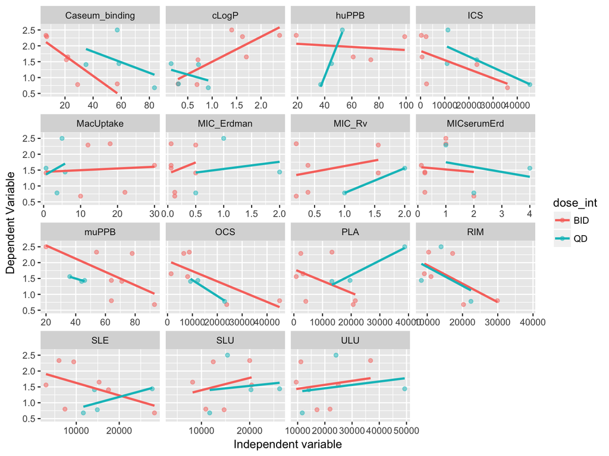

- It appears that the relationship between independent and dependent variables are dependent on dose for variables cLogP, huPPB, PLA, and SLE. The others are not dependent on dose.
- Dose may be an important factor to consider when evaluating the relationship between independent and dependent variables.

## Fitting Linear Models Function

I fitted a linear model regressing dependent on independent variables to assess the relationships between them. Inputs to this function include peak_trough (options are Cmax or trough), or the dep_var (options are ELU or ESP). The units of scale for each variable were normalized so that we could compare across coeficients.

# Coefficients Plot

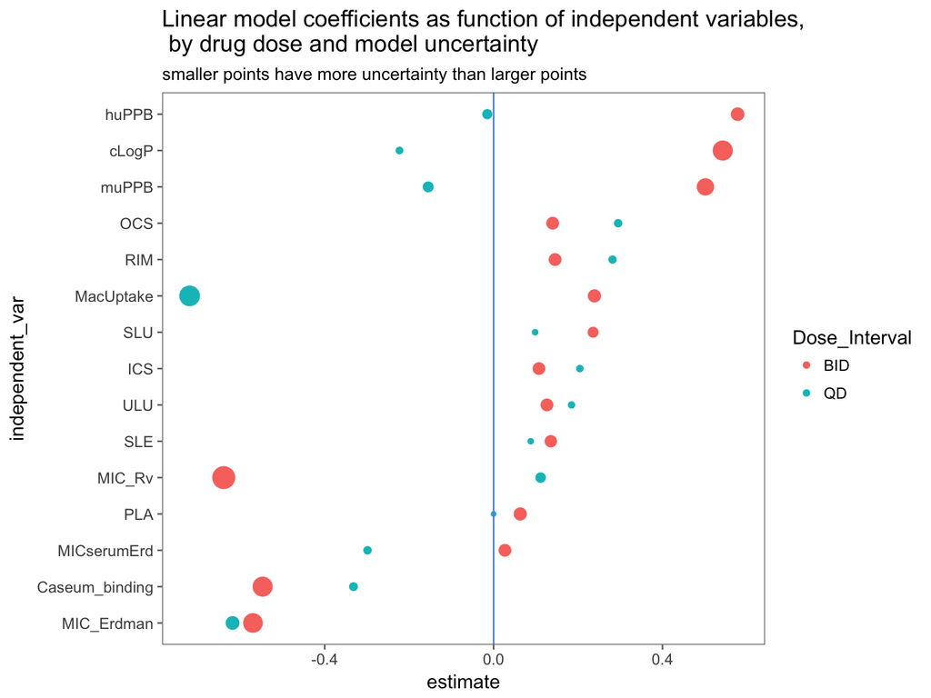

## Regression Tree Function

## Testing regression_tree function

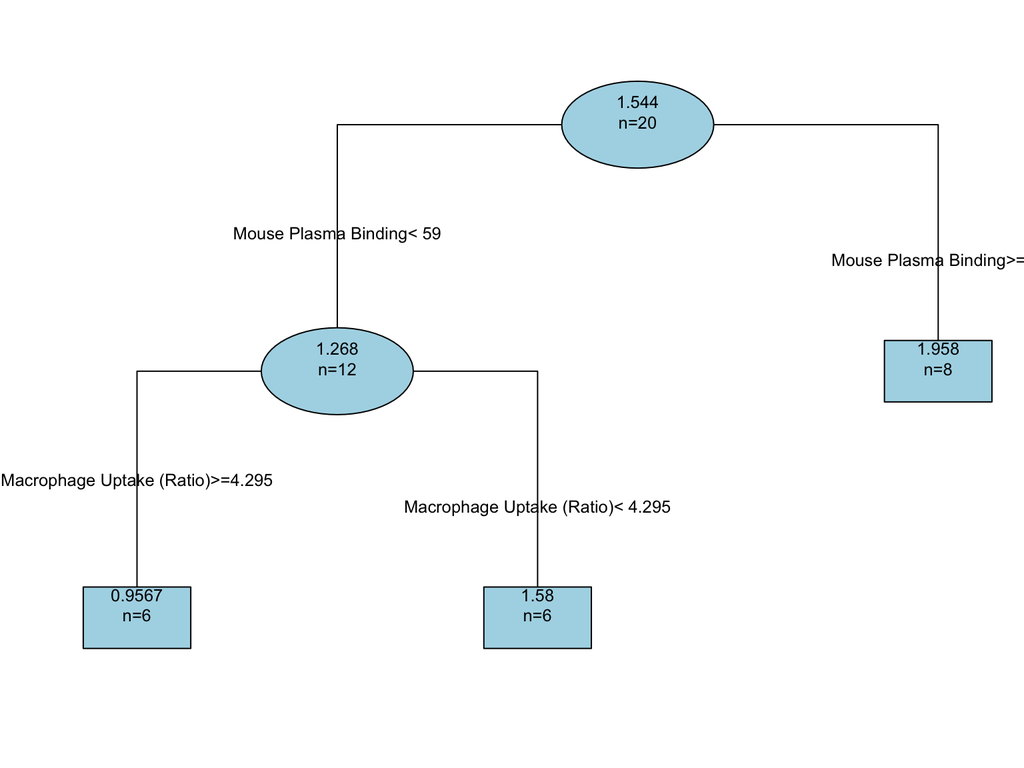

## LASSO Function

The function for LASSO required the following inputs:

- Dependant varaible
- Dose
- Dataframe, though the dataframe default is efficacy_summary

The output in the end is coefficients with smaller coefficients being resitricted to zero.

## RandomForest Function

- The user specifies which dependent variable they would like to use (either ELU or ESP). The user can also specify a dataset they would like to use, if one is not provided then a default dataset is utilized. The function var_importance takes the input and outputs a graph displaying the which variables are the best predictors of the input (either ELU or ESP).

## Testing Random Forest

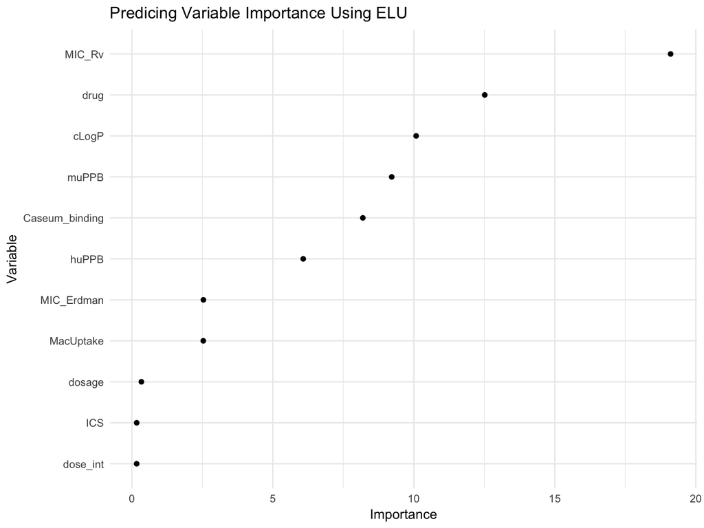

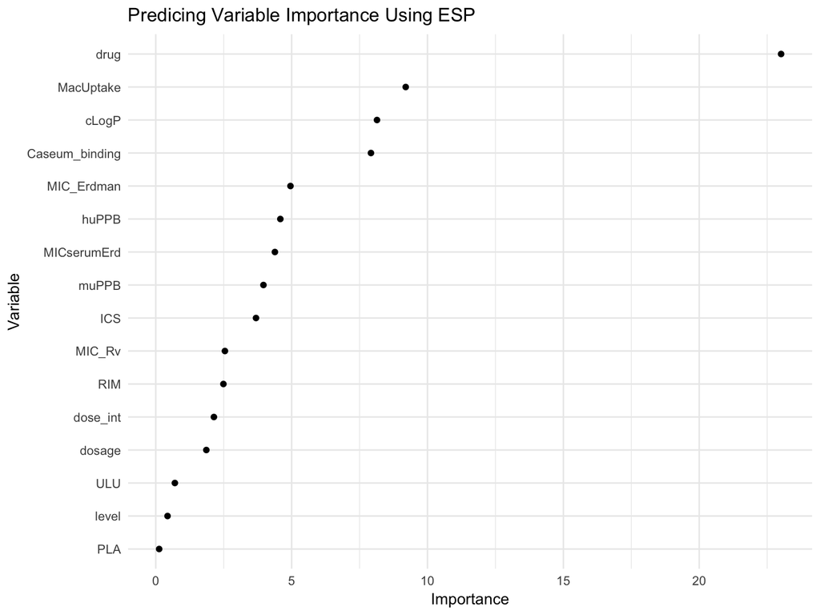

## Interpretation

- This function utilizes the function randomForest to predict which variables are the most important predictors of the associated outcome. This model works by randomly creating small data nodes that are split using the best predictor from a subset of predictors randomly chosen at each node. In order to determine variable importance, the algorithm looks at how much the predictive error increases as all variables remain unchanged while one is permuted. The resulting output shows the % increase in the mean standard error for each variable considered individually. The higher the number the more important the variable for model building.